title: “HA - Data Science (modelling)” author: “Gabor Kaposztassy” date: “6th March, 2016” output: html_document: fig_height: 4 fig_width: 6 toc: true toc_depth: 3

## # Data analysis project

Data are from: http://archive.ics.uci.edu/ml/datasets/Diabetes+130-US+hospitals+for+years+1999-2008# Reference research: http://www.hindawi.com/journals/bmri/2014/781670/

Loading libraries and initialize H2O

```r
library(dummies)
library(data.table)
library(reshape)
library(dplyr)
library(ggplot2)
library(ROCR)
library(pander)
library(knitr)
library(h2o)
library(stats)
library(randomForest)
library(arm)
library(rpart)
library(gbm)

h2o.init(max_mem_size = "4g", nthreads = -1)
```

```
## Successfully connected to http://127.0.0.1:54321/
##
## R is connected to the H2O cluster:
##     H2O cluster uptime:         13 hours 7 minutes
##     H2O cluster version:        3.6.0.8
##     H2O cluster name:           H2O_started_from_R_KG_nvc047
##     H2O cluster total nodes:    1
##     H2O cluster total memory:   3.56 GB
##     H2O cluster total cores:    4
##     H2O cluster allowed cores:  4
##     H2O cluster healthy:        TRUE
```

```
## IP Address: 127.0.0.1
## Port      : 54321
## Session ID: _sid_b56a5cb73d58621dd5fc5d7102d340c9
## Key Count : 0
```

## ## Exploratory Analysis

### Read data and quick look

We have a dataset about hospital visitors with several parameters and the task to predict whether the patient will be early readmitted (withing 30 days). The original aim of the documented analysis was to improve the reason of a specific test (HA1C) for diabetic disease that may lower the cost of the readmission.

First let us look at the data.

Our target (readmitted<30) is about 11% of all data and we have three variable with many NAs.

|  | encounter_id | patient_nbr | race | gender | age | weight | admission_type_id | discharge_disposition_id | admission_source_id | time_in_hospital | payer_code | medical_specialty | num_lab_procedures | num_procedures | num_medications | number_outpatient | number_emergency | number_inpatient | diag_1 | diag_2 | diag_3 | number_diagnoses | max_glu_serum | A1Cresult | metformin | repaglinide | nateglinide | chlorpropamide | glimepiride | … |
| --- | --- | --- | --- | --- | --- | --- | --- | --- | --- | --- | --- | --- | --- | --- | --- | --- | --- | --- | --- | --- | --- | --- | --- | --- | --- | --- | --- | --- | --- | --- |
|  | Min. : 12522 | Min. : 135 | Length:101766 | Length:101766 | Length:101766 | Length:101766 | Min. :1.000 | Min. : 1.000 | Min. : 1.000 | Min. : 1.000 | Length:101766 | Length:101766 | Min. : 1.0 | Min. :0.00 | Min. : 1.00 | Min. : 0.0000 | Min. : 0.0000 | Min. : 0.0000 | Length:101766 | Length:101766 | Length:101766 | Min. : 1.000 | Length:101766 | Length:101766 | Length:101766 | Length:101766 | Length:101766 | Length:101766 | Length:101766 | … |
|  | 1st Qu.: 84961194 | 1st Qu.: 23413221 | Class :character | Class :character | Class :character | Class :character | 1st Qu.:1.000 | 1st Qu.: 1.000 | 1st Qu.: 1.000 | 1st Qu.: 2.000 | Class :character | Class :character | 1st Qu.: 31.0 | 1st Qu.:0.00 | 1st Qu.:10.00 | 1st Qu.: 0.0000 | 1st Qu.: 0.0000 | 1st Qu.: 0.0000 | Class :character | Class :character | Class :character | 1st Qu.: 6.000 | Class :character | Class :character | Class :character | Class :character | Class :character | Class :character | Class :character | … |
|  | Median :152388987 | Median : 45505143 | Mode :character | Mode :character | Mode :character | Mode :character | Median :1.000 | Median : 1.000 | Median : 7.000 | Median : 4.000 | Mode :character | Mode :character | Median : 44.0 | Median :1.00 | Median :15.00 | Median : 0.0000 | Median : 0.0000 | Median : 0.0000 | Mode :character | Mode :character | Mode :character | Median : 8.000 | Mode :character | Mode :character | Mode :character | Mode :character | Mode :character | Mode :character | Mode :character | … |
|  | Mean :165201646 | Mean : 54330401 | NA | NA | NA | NA | Mean :2.024 | Mean : 3.716 | Mean : 5.754 | Mean : 4.396 | NA | NA | Mean : 43.1 | Mean :1.34 | Mean :16.02 | Mean : 0.3694 | Mean : 0.1978 | Mean : 0.6356 | NA | NA | NA | Mean : 7.423 | NA | NA | NA | NA | NA | NA | NA | … |
|  | 3rd Qu.:230270888 | 3rd Qu.: 87545950 | NA | NA | NA | NA | 3rd Qu.:3.000 | 3rd Qu.: 4.000 | 3rd Qu.: 7.000 | 3rd Qu.: 6.000 | NA | NA | 3rd Qu.: 57.0 | 3rd Qu.:2.00 | 3rd Qu.:20.00 | 3rd Qu.: 0.0000 | 3rd Qu.: 0.0000 | 3rd Qu.: 1.0000 | NA | NA | NA | 3rd Qu.: 9.000 | NA | NA | NA | NA | NA | NA | NA | … |
|  | Max. :443867222 | Max. :189502619 | NA | NA | NA | NA | Max. :8.000 | Max. :28.000 | Max. :25.000 | Max. :14.000 | NA | NA | Max. :132.0 | Max. :6.00 | Max. :81.00 | Max. :42.0000 | Max. :76.0000 | Max. :21.0000 | NA | NA | NA | Max. :16.000 | NA | NA | NA | NA | NA | NA | NA | … |

Target variable

```
## Source: local data frame [3 x 3]
##
##   readmitted     n        %
##        (chr) (int)    (dbl)
## 1        <30 11357 11.15992
## 2        >30 35545 34.92817
## 3         NO 54864 53.91192
```

NA ratio of variables

```
##                                    .
## encounter_id              0.00000000
## patient_nbr               0.00000000
## race                      2.23355541
## gender                    0.00000000
## age                       0.00000000
## weight                   96.85847926
## admission_type_id         0.00000000
## discharge_disposition_id  0.00000000
## admission_source_id       0.00000000
## time_in_hospital          0.00000000
## payer_code               39.55741603
## medical_specialty        49.08220820
## num_lab_procedures        0.00000000
## num_procedures            0.00000000
## num_medications           0.00000000
## number_outpatient         0.00000000
## number_emergency          0.00000000
## number_inpatient          0.00000000
## diag_1                    0.02063558
## diag_2                    0.35178743
## diag_3                    1.39830592
## number_diagnoses          0.00000000
## max_glu_serum             0.00000000
## A1Cresult                 0.00000000
## metformin                 0.00000000
## repaglinide               0.00000000
## nateglinide               0.00000000
## chlorpropamide            0.00000000
## glimepiride               0.00000000
## acetohexamide             0.00000000
## glipizide                 0.00000000
## glyburide                 0.00000000
## tolbutamide               0.00000000
## pioglitazone              0.00000000
## rosiglitazone             0.00000000
## acarbose                  0.00000000
## miglitol                  0.00000000
## troglitazone              0.00000000
## tolazamide                0.00000000
## examide                   0.00000000
## citoglipton               0.00000000
## insulin                   0.00000000
## glyburide.metformin       0.00000000
## glipizide.metformin       0.00000000
## glimepiride.pioglitazone  0.00000000
## metformin.rosiglitazone   0.00000000
## metformin.pioglitazone    0.00000000
## change                    0.00000000
## diabetesMed               0.00000000
## readmitted                0.00000000
## target                    0.00000000
```

### Getting know main predictor variables

By a preceding analysis I present the predictor variables in their importance order.

### *Medical specialty*

Integer identifier of a specialty of the admitting physician with 73 unique value end 49% NA. The distribution of physicians within target (1) and others (0).

Using % as value column. Use the value argument to cast to override this choice

| medical_specialty | 0 | 1 |
| --- | --- | --- |
| NA | 48.85 | 50.9 |
| InternalMedicine | 14.37 | 14.49 |
| Family/GeneralPractice | 7.253 | 7.775 |
| Emergency/Trauma | 7.432 | 7.449 |
| Cardiology | 5.45 | 3.742 |
| Surgery-General | 3.049 | 3.011 |
| Nephrology | 1.51 | 2.184 |
| Orthopedics | 1.381 | 1.33 |
| Psychiatry | 0.8296 | 0.9157 |
| Radiologist | 1.147 | 0.9069 |
| Pulmonology | 0.8572 | 0.8453 |
| Orthopedics-Reconstructive | 1.262 | 0.8101 |
| Surgery-Vascular | 0.5077 | 0.6516 |
| Urology | 0.6825 | 0.5987 |
| Oncology | 0.3119 | 0.5811 |
| Gastroenterology | 0.5553 | 0.5459 |
| PhysicalMedicineandRehabilitation | 0.3661 | 0.5283 |
| Surgery-Cardiovascular/Thoracic | 0.6736 | 0.3786 |
| Hematology/Oncology | 0.1847 | 0.3522 |
| ObstetricsandGynecology | 0.7068 | 0.2818 |
| Surgery-Neuro | 0.4823 | 0.2818 |
| Hematology | 0.06194 | 0.2289 |
| Pediatrics | 0.2632 | 0.1409 |
| Neurology | 0.2113 | 0.1057 |
| Surgery-Thoracic | 0.1084 | 0.09686 |
| Podiatry | 0.09955 | 0.08805 |
| Psychology | 0.1029 | 0.07044 |
| Radiology | 0.04977 | 0.07044 |
| InfectiousDiseases | 0.03208 | 0.07044 |
| Surgery-Plastic | 0.03761 | 0.06164 |
| Endocrinology | 0.1261 | 0.05283 |
| Surgery-Cardiovascular | 0.1018 | 0.05283 |
| Hospitalist | 0.05862 | 0.03522 |
| Surgeon | 0.04535 | 0.03522 |
| Pediatrics-CriticalCare | 0.09291 | 0.02642 |
| Osteopath | 0.03982 | 0.02642 |
| Rheumatology | 0.01549 | 0.02642 |
| AllergyandImmunology | 0.004424 | 0.02642 |
| Otolaryngology | 0.136 | 0.01761 |
| Ophthalmology | 0.03982 | 0.01761 |
| SurgicalSpecialty | 0.03429 | 0.01761 |
| Obsterics&Gynecology-GynecologicOnco | 0.02544 | 0.01761 |
| Pediatrics-Pulmonology | 0.02544 | 0.01761 |
| PhysicianNotFound | 0.009955 | 0.01761 |
| Pediatrics-Endocrinology | 0.1748 | 0.008805 |
| Anesthesiology-Pediatric | 0.01991 | 0.008805 |
| Obstetrics | 0.01991 | 0.008805 |
| Pathology | 0.0177 | 0.008805 |
| Anesthesiology | 0.01217 | 0.008805 |
| OutreachServices | 0.01217 | 0.008805 |
| Surgery-Colon&Rectal | 0.01106 | 0.008805 |
| Surgery-Maxillofacial | 0.01106 | 0.008805 |
| Endocrinology-Metabolism | 0.007743 | 0.008805 |
| Cardiology-Pediatric | 0.006637 | 0.008805 |
| Psychiatry-Child/Adolescent | 0.006637 | 0.008805 |
| Pediatrics-Hematology-Oncology | 0.003318 | 0.008805 |
| Resident | 0.001106 | 0.008805 |
| Gynecology | 0.06415 | NA |
| Pediatrics-Neurology | 0.01106 | NA |
| Surgery-Pediatric | 0.008849 | NA |
| DCPTEAM | 0.006637 | NA |
| Dentistry | 0.004424 | NA |
| Pediatrics-AllergyandImmunology | 0.003318 | NA |
| Pediatrics-EmergencyMedicine | 0.003318 | NA |
| Dermatology | 0.001106 | NA |
| Neurophysiology | 0.001106 | NA |
| Pediatrics-InfectiousDiseases | 0.001106 | NA |
| Perinatology | 0.001106 | NA |
| Proctology | 0.001106 | NA |
| Psychiatry-Addictive | 0.001106 | NA |
| Speech | 0.001106 | NA |
| SportsMedicine | 0.001106 | NA |
| Surgery-PlasticwithinHeadandNeck | 0.001106 | NA |

### *Number of lab procedures*

Number of lab tests performed during the encounter with no NA but some extreme value.

```
##    Min. 1st Qu.  Median    Mean 3rd Qu.    Max.
##     1.0    31.0    44.0    43.1    57.0   132.0
```

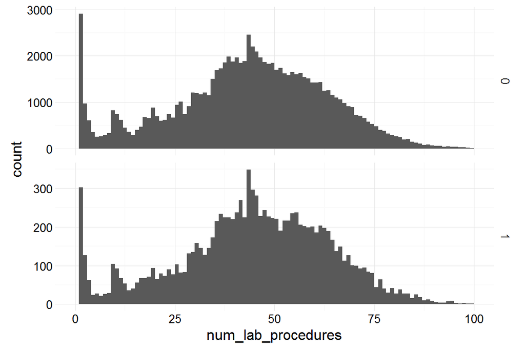

### *Number of inpatient*

Number of inpatient visits of the patient in the year preceding the encounter.

```
##    Min. 1st Qu.  Median    Mean 3rd Qu.    Max.
##  0.0000  0.0000  0.0000  0.6356  1.0000 21.0000
```

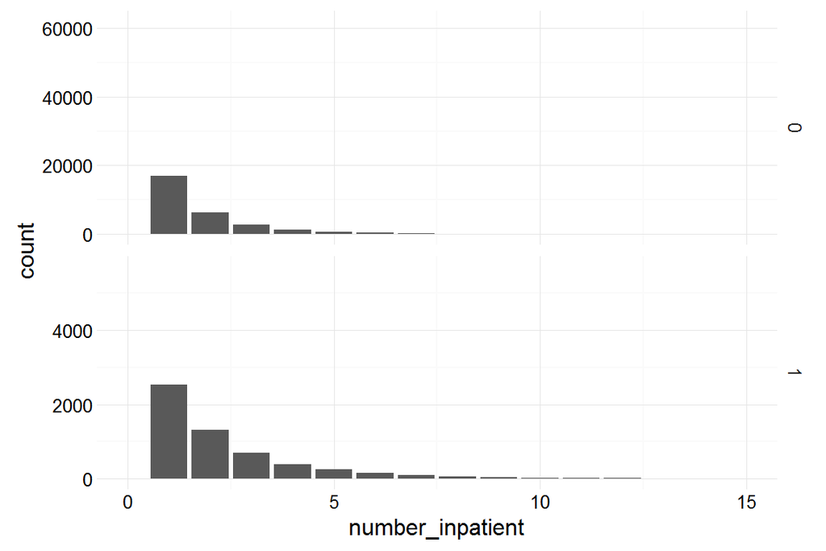

### *Time in hospital*

Integer number of days between admission and discharge.

```
##    Min. 1st Qu.  Median    Mean 3rd Qu.    Max.
##   1.000   2.000   4.000   4.396   6.000  14.000
```

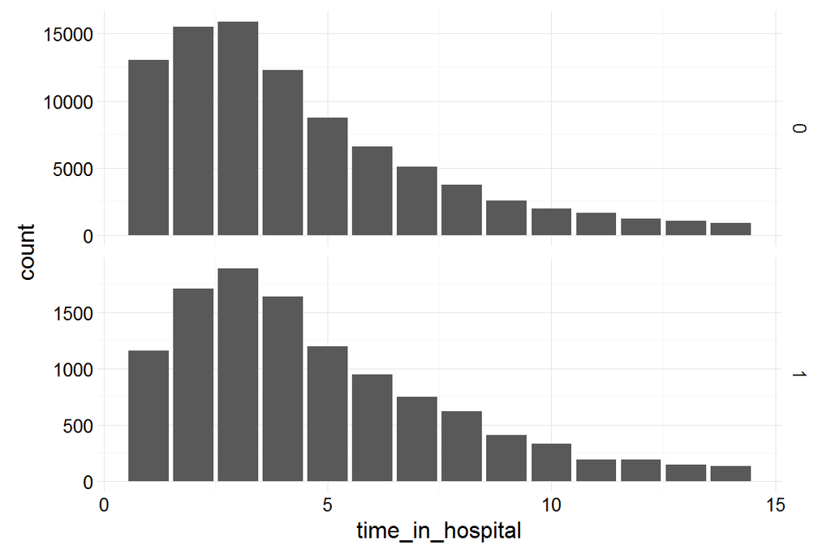

### *Age*

Nominal variable grouped in 10-year intervals: 0, 10), 10, 20), …, 90, 100).

```
##
##   [0-10)  [10-20)  [20-30)  [30-40)  [40-50)  [50-60)  [60-70)  [70-80)
##      161      691     1657     3775     9685    17256    22483    26068
##  [80-90) [90-100)
##    17197     2793
```

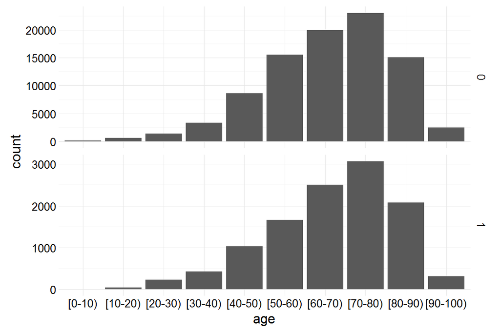

### *Number of medications*

Number of distinct generic names administered during the encounter.

```
##    Min. 1st Qu.  Median    Mean 3rd Qu.    Max.
##    1.00   10.00   15.00   16.02   20.00   81.00
```

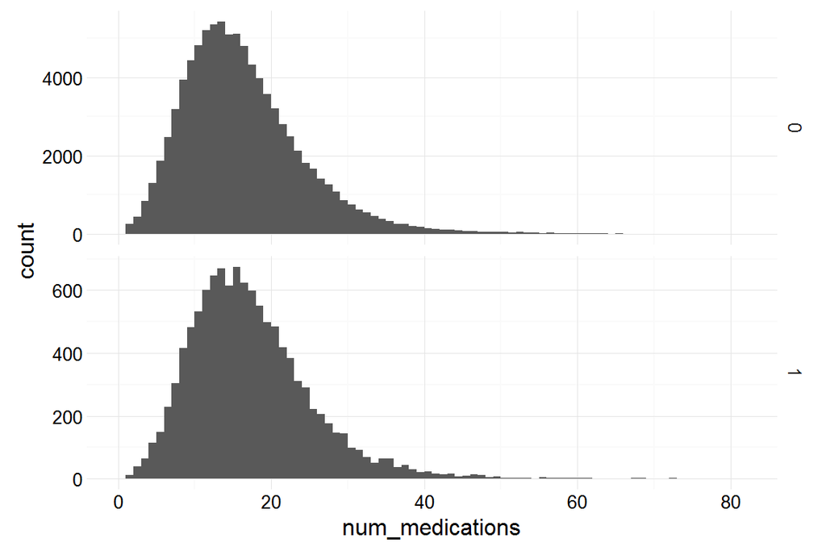

### *Payer code*

Integer identifier corresponding to 18 distinct values (including self-pay and other types) with 40% NA.

```
## [1] 18
```

```
##    payer_code     n    %
## 1          BC  4655  4.6
## 2          CH   146  0.1
## 3          CM  1937  1.9
## 4          CP  2533  2.5
## 5          DM   549  0.5
## 6          FR     1  0.0
## 7          HM  6274  6.2
## 8          MC 32439 31.9
## 9          MD  3532  3.5
## 10         MP    79  0.1
## 11         OG  1033  1.0
## 12         OT    95  0.1
## 13         PO   592  0.6
## 14         SI    55  0.1
## 15         SP  5007  4.9
## 16         UN  2448  2.4
## 17         WC   135  0.1
## 18       <NA> 40256 39.6
```

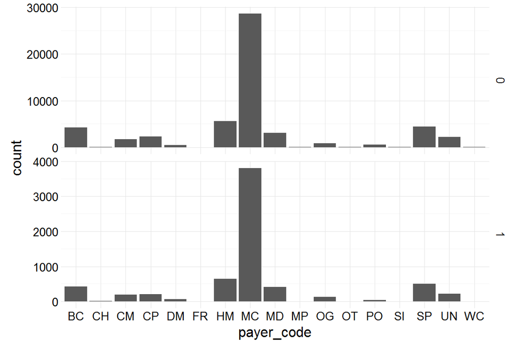

### *Diagnosis 1,2,3*

The primary, secondary and alternative secondary diagnosis (coded as first three digits of ICD9) preceeding the encounter. Unique values are over 700, this needs feature engeneering.

```
## [1] 717
```

```
## [1] 749
```

```
## [1] 790
```

### *Admission source*

Integer identifier corresponding to 17 distinct values, for example, physician referral, emergency room, and transfer from a hospital

```
##    admission_source_id     n    %
## 1                    1 29565 29.1
## 2                    2  1104  1.1
## 3                    3   187  0.2
## 4                    4  3187  3.1
## 5                    5   855  0.8
## 6                    6  2264  2.2
## 7                    7 57494 56.5
## 8                    8    16  0.0
## 9                    9   125  0.1
## 10                  10     8  0.0
## 11                  11     2  0.0
## 12                  13     1  0.0
## 13                  14     2  0.0
## 14                  17  6781  6.7
## 15                  20   161  0.2
## 16                  22    12  0.0
## 17                  25     2  0.0
```

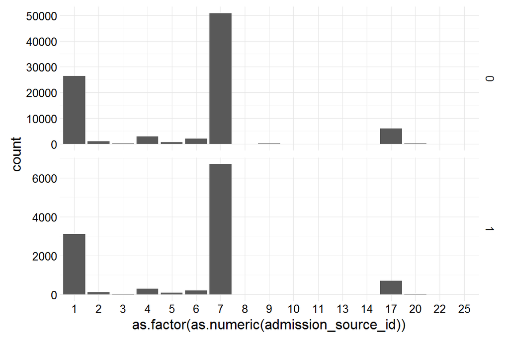

### *Discharge disposition*

Integer identifier corresponding to 26 distinct values, for example, discharged to home, expired, and not available.

```
##    discharge_disposition_id     n    %
## 1                         1 60234 59.2
## 2                         2  2128  2.1
## 3                         3 13954 13.7
## 4                         4   815  0.8
## 5                         5  1184  1.2
## 6                         6 12902 12.7
## 7                         7   623  0.6
## 8                         8   108  0.1
## 9                         9    21  0.0
## 10                       10     6  0.0
## 11                       11  1642  1.6
## 12                       12     3  0.0
## 13                       13   399  0.4
## 14                       14   372  0.4
## 15                       15    63  0.1
## 16                       16    11  0.0
## 17                       17    14  0.0
## 18                       18  3691  3.6
## 19                       19     8  0.0
## 20                       20     2  0.0
## 21                       22  1993  2.0
## 22                       23   412  0.4
## 23                       24    48  0.0
## 24                       25   989  1.0
## 25                       27     5  0.0
## 26                       28   139  0.1
```

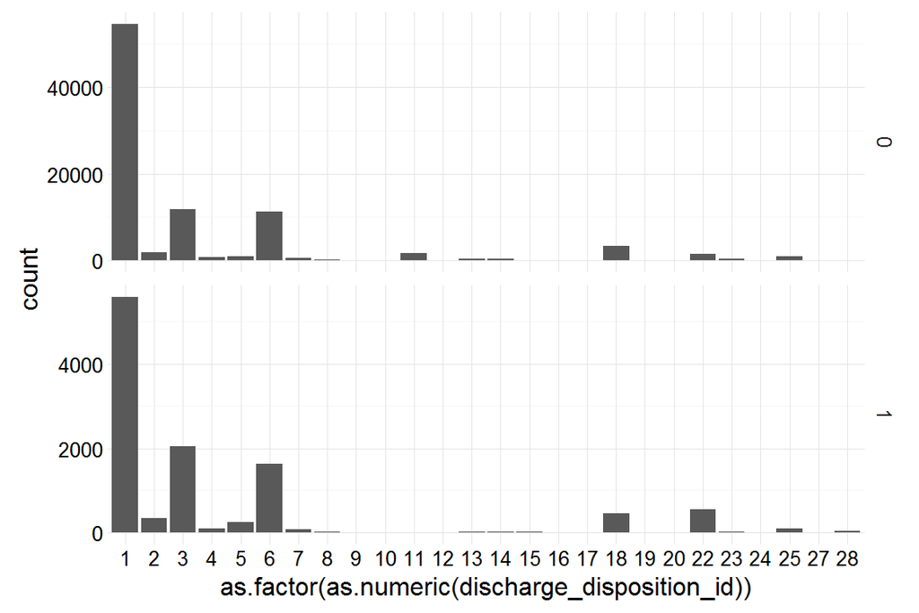

### *A1C test result*

Indicates the range of the result or if the test was not taken. Values: “>8” if the result was greater than 8%, “>7” if the result was greater than 7% but less than 8%, “normal” if the result was less than 7%, and “none” if not measured. It seems to be significant to the outcome. A1c test was performed in 17% of encounters. Basically the early readmittance is some higher in the case of no A1c test.

```
##   A1Cresult     0    1          %
## 1        >7  3429  383 0.10047219
## 2        >8  7405  811 0.09870983
## 3      None 75067 9681 0.11423278
## 4      Norm  4508  482 0.09659319
```

## Feature engeneering

I followed the rule of thumb to convert (cathegory) variables to dummies (NAs as well) but I also left the original data frame with the target dummy as well to try the algorithms on it.

I used the cathegory info on diagnosis data:

“circulatory” for icd9: 390-459, 785, “digestive” for icd9: 520-579, 787, “genitourinary” for icd9: 580-629, 788, “diabetes” for icd9: 250.xx, “injury” for icd9: 800-999, “musculoskeletal” for icd9: 710-739, “neoplasms” for icd9: 140-239, “respiratory” for icd9: 460-519, 786, and “other”.

And I dropped variables with one unique values, and I kept weight in spite of 96% NA, but I coded it as dummy. I dropped only 3 rows due to invalid gender.

```r
fdiag <- function(column) {
  sapply(column, function(x) {
    x = as.character(x)
    res = "NA"
    if(!is.na(x)){
      res = "other"
      if ((x>='390' & x<='459') | x =='785') {res = 'circulatory'}
      if ((x>='520' & x<='579') | x =='787') {res = 'digestive'}
      if ((x>='580' & x<='629') | x =='788') {res = 'genitourinary'}
      if (x %like% '250') {res = 'diabetes'}
      if (x>='800' & x<='999') {res = 'injury'}
      if (x>='710' & x<='739') {res = 'musculoskeletal'}
      if (x>='140' & x<='239') {res = 'neoplasms'}
      if ((x>='460' & x<='519') | x =='786') {res = 'respiratory'}
      }
    res
  }, USE.NAMES = F, simplify = T)
}


dt <- dt %>% mutate(
    admission_type_id = as.character(admission_type_id),
    discharge_disposition_id = as.character(discharge_disposition_id),
    admission_source_id = as.character(admission_source_id),
    diag1 = fdiag(diag_1),
    diag2 = fdiag(diag_2),
    diag3 = fdiag(diag_3)
)

dt$diag_1 <- NULL
dt$diag_2 <- NULL
dt$diag_3 <- NULL
dt$examide <- NULL
dt$citoglipton <- NULL
dt$encounter_id <- NULL
dt$patient_nbr <- NULL
dt$A1Ctest <- 1-as.numeric(dt$A1Cresult =='None')
dt$A1Cresult <- NULL

# target back to the end!!!
dt$target <- NULL
dt$target<- as.numeric(dt$readmitted=='<30')
dt$readmitted <- NULL


dt[is.na(dt)]<-"x"
dt <- dt[dt$gender != "Unknown/Invalid", ]
df <- dt
df[, lapply(df, class) == "character"] <- lapply(df[, lapply(df, class) == "character"], as.factor)

dd <- dummy.data.frame(dt)

ddf <- as.data.frame(lapply(dd[,names(dd)], factor))
ddf <- ddf %>% mutate(
  time_in_hospital = as.numeric(time_in_hospital),
  num_lab_procedures = as.numeric(num_lab_procedures),
  num_procedures = as.numeric(num_procedures),
  num_medications = as.numeric(num_medications),
  number_outpatient = as.numeric(number_outpatient),
  number_emergency = as.numeric(number_emergency),
  number_inpatient = as.numeric(number_inpatient),
  number_diagnoses = as.numeric(number_diagnoses)
)

# this way did not work together with randomForest
# ddf[,!names(dd)%like%"num" & names(dd)!="time_in_hospital"] <- as.data.frame(lapply(dd[,!names(dd)%like%"num" & names(dd)!="time_in_hospital"], factor))
```

## Modelling

I tried the following R modells: Logistic regression, Classification Decision tree, Random Forest, Gradient Boost Method. After this I tried out H2O models with similar and changed parameters as well. GLM and RandomForest needed dummized varibles, and RF liked factors much more, but othe algorithms could deal without dummies.

### GLM

First I run a linear regression to see quickly the prediction power of the variables, and check if the A1C test has any significant effect to the early readmission.

```r
# glm needs dummies


glmtim <- Sys.time()
lgb <- bayesglm(target~.,dd_train,family="binomial")
glmtim <- Sys.time() - glmtim

# this does not work due to perfect separation error...
#lgb <- glm(target~.,dd_train,family="binomial")
summary(lgb)
```

```
##
## Call:
## bayesglm(formula = target ~ ., family = "binomial", data = dd_train)
##
## Deviance Residuals:
##     Min       1Q   Median       3Q      Max
## -2.6236  -0.5027  -0.4192  -0.3472   2.7793
##
## Coefficients:
##                                                           Estimate
## (Intercept)                                             -5.896e+00
## raceAfricanAmerican                                      5.576e-02
## raceAsian                                                1.084e-02
## raceCaucasian                                            6.613e-02
## raceHispanic                                             9.288e-02
## raceOther                                               -6.282e-02
## racex                                                   -1.634e-01
## genderFemale                                            -1.577e-02
## genderMale                                               1.577e-02
## `age[0-10)`                                             -5.089e-01
## `age[10-20)`                                            -2.084e-01
## `age[20-30)`                                             2.554e-01
## `age[30-40)`                                             1.173e-01
## `age[40-50)`                                             3.733e-02
## `age[50-60)`                                            -5.969e-02
## `age[60-70)`                                             7.842e-02
## `age[70-80)`                                             1.101e-01
## `age[80-90)`                                             1.363e-01
## `age[90-100)`                                           -2.934e-03
## `weight[0-25)`                                           3.808e-01
## `weight[100-125)`                                        1.008e-01
## `weight[125-150)`                                       -3.013e-01
## `weight[150-175)`                                        5.884e-01
## `weight[175-200)`                                        3.340e-01
## `weight[25-50)`                                         -5.454e-01
## `weight[50-75)`                                         -1.667e-01
## `weight[75-100)`                                         8.924e-02
## `weight>200`                                            -3.335e-01
## weightx                                                 -1.991e-01
## admission_type_id1                                       6.643e-02
```

[output cut: 828 more lines]

```
## diag3NA                                                 0.771900
## diag3neoplasms                                          0.670662
## diag3other                                              0.980123
## diag3respiratory                                        0.997997
## A1Ctest                                                 0.000232 ***
## ---
## Signif. codes:  0 '***' 0.001 '**' 0.01 '*' 0.05 '.' 0.1 ' ' 1
##
## (Dispersion parameter for binomial family taken to be 1)
##
##     Null deviance: 35529  on 50880  degrees of freedom
## Residual deviance: 33187  on 50594  degrees of freedom
## AIC: 33761
##
## Number of Fisher Scoring iterations: 15
```

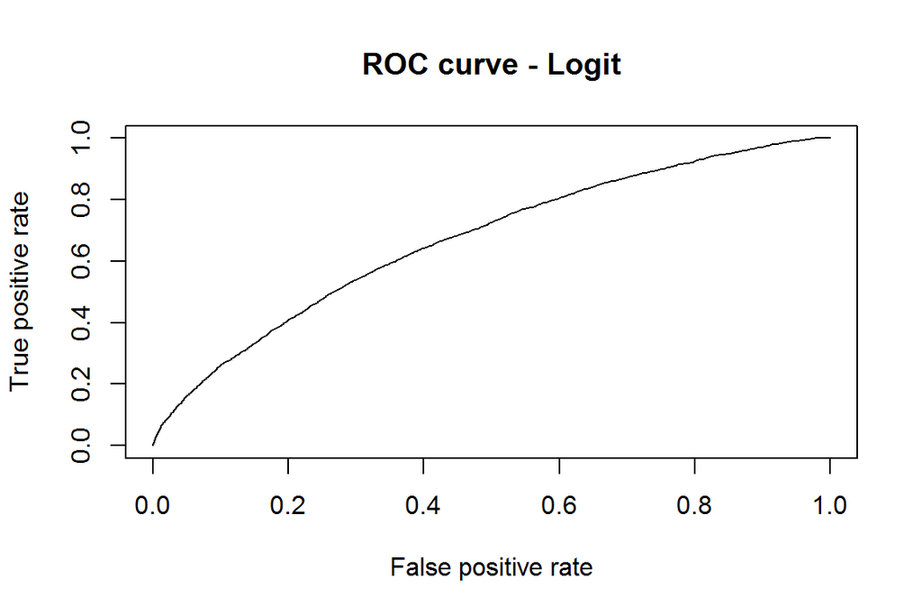

```r
pred_lgb <- prediction(as.data.frame(predict(lgb,dd_test))[,1],dd_test$target)

# MSE
glmmse <- mean(as.data.frame(predict(lgb,dd_test))[,1]-dd_test$target)^2
# ROC
plot(performance(pred_lgb,"tpr","fpr"), main="ROC curve - Logit")
```

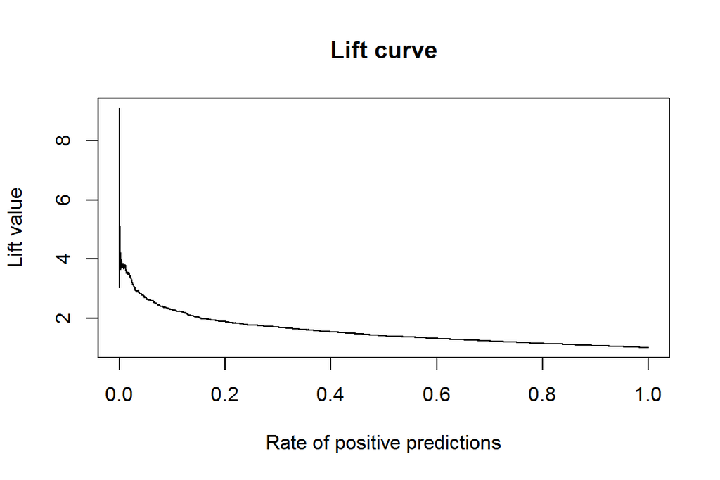

```r
# lift chart
plot(performance(pred_lgb,"lift","rpp"), main="Lift curve")
```

```r
#AUC
glmauc <- as.numeric(performance(pred_lgb,"auc")@y.values)

lgb
```

```
##
## Call:  bayesglm(formula = target ~ ., family = "binomial", data = dd_train)
##
## Coefficients:
##                                             (Intercept)
##                                              -5.896e+00
##                                     raceAfricanAmerican
##                                               5.576e-02
##                                               raceAsian
##                                               1.084e-02
##                                           raceCaucasian
##                                               6.613e-02
##                                            raceHispanic
##                                               9.288e-02
##                                               raceOther
##                                              -6.282e-02
##                                                   racex
##                                              -1.634e-01
##                                            genderFemale
##                                              -1.577e-02
##                                              genderMale
##                                               1.577e-02
##                                             `age[0-10)`
##                                              -5.089e-01
##                                            `age[10-20)`
##                                              -2.084e-01
##                                            `age[20-30)`
##                                               2.554e-01
##                                            `age[30-40)`
##                                               1.173e-01
##                                            `age[40-50)`
##                                               3.733e-02
##                                            `age[50-60)`
##                                              -5.969e-02
##                                            `age[60-70)`
##                                               7.842e-02
##                                            `age[70-80)`
##                                               1.101e-01
##                                            `age[80-90)`
##                                               1.363e-01
```

[output cut: 527 more lines]

```
##                                              -1.207e-01
##                                                 diag3NA
##                                              -1.729e-01
##                                          diag3neoplasms
##                                               2.476e-01
##                                              diag3other
##                                              -1.434e-02
##                                        diag3respiratory
##                                               1.449e-03
##                                                 A1Ctest
##                                              -1.590e-01
##
## Degrees of Freedom: 50880 Total (i.e. Null);  50594 Residual
## Null Deviance:       35530
## Residual Deviance: 33190     AIC: 33760
```

```r
pander(c(mse=glmmse,auc=glmauc,time=glmtim))
```

| mse | auc | time |
| --- | --- | --- |
| 5.792 | 0.6683 | 3.436 |

### Decision tree

```r
dectim <- Sys.time()
dect <- rpart(target ~ ., data = df_train, control = rpart.control(cp = 0))
dectim <- Sys.time() - dectim

#summary(dect)

as.data.frame(dect$variable.importance)
```

```
##                          dect$variable.importance
## num_lab_procedures                   2.225252e+02
## medical_specialty                    2.215021e+02
## age                                  2.072846e+02
## diag1                                2.040990e+02
## num_medications                      1.883683e+02
## diag2                                1.883632e+02
## diag3                                1.869178e+02
## payer_code                           1.790385e+02
## discharge_disposition_id             1.647915e+02
## number_inpatient                     1.517673e+02
## time_in_hospital                     1.473869e+02
## admission_source_id                  1.294377e+02
## admission_type_id                    1.211672e+02
## insulin                              9.483201e+01
## num_procedures                       8.399092e+01
## race                                 7.122092e+01
## number_diagnoses                     6.958142e+01
## number_emergency                     3.677687e+01
## number_outpatient                    3.168345e+01
## metformin                            3.137060e+01
## change                               3.122664e+01
## gender                               2.787777e+01
## glipizide                            2.699457e+01
## max_glu_serum                        2.669149e+01
## A1Ctest                              2.318740e+01
## diabetesMed                          2.074932e+01
## weight                               1.935489e+01
## glyburide                            1.609383e+01
## pioglitazone                         1.231531e+01
## glimepiride                          1.089520e+01
## rosiglitazone                        9.425516e+00
## repaglinide                          6.889169e+00
## glyburide.metformin                  1.771263e+00
## nateglinide                          1.692919e+00
## acarbose                             1.612322e+00
## miglitol                             1.998454e-01
## tolbutamide                          1.713622e-01
## chlorpropamide                       1.079666e-01
## glipizide.metformin                  2.840624e-02
## glimepiride.pioglitazone             2.476839e-02
## tolazamide                           1.359609e-02
## troglitazone                         7.148182e-03
## metformin.rosiglitazone              3.174742e-03
```

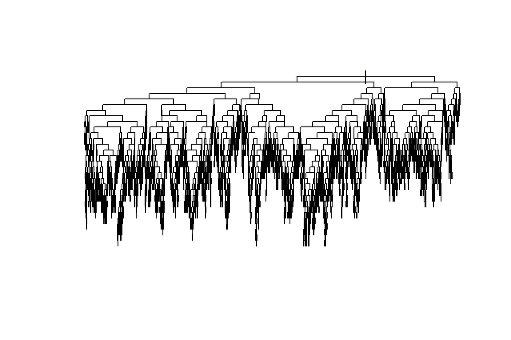

```r
plot(dect, uniform = TRUE, compress = TRUE)
```

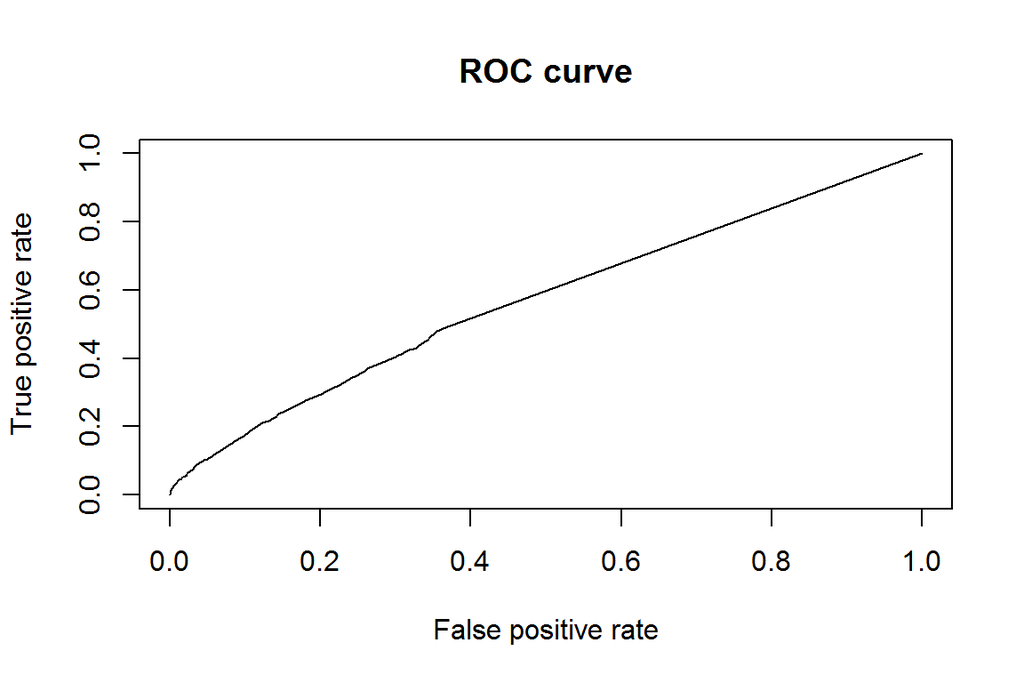

```r
pred_dec <- prediction(as.data.frame(predict(dect, df_test)), df_test$target)

# MSE
decmse <- mean((as.data.frame(predict(dect, df_test))[,1]- df_test$target)^2)
# ROC
plot(performance(pred_dec,"tpr","fpr"), main="ROC curve")
```

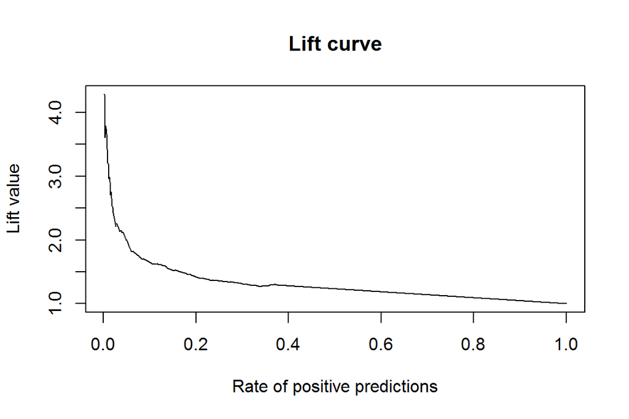

```r
# lift chart
plot(performance(pred_dec,"lift","rpp"), main="Lift curve")
```

```r
#AUC
decauc <- as.numeric(performance(pred_dec,"auc")@y.values)

pander(c(mse=decmse,auc=decauc,time=dectim))
```

| mse | auc | time |
| --- | --- | --- |
| 0.1239 | 0.5711 | 34 |

### Random Forest

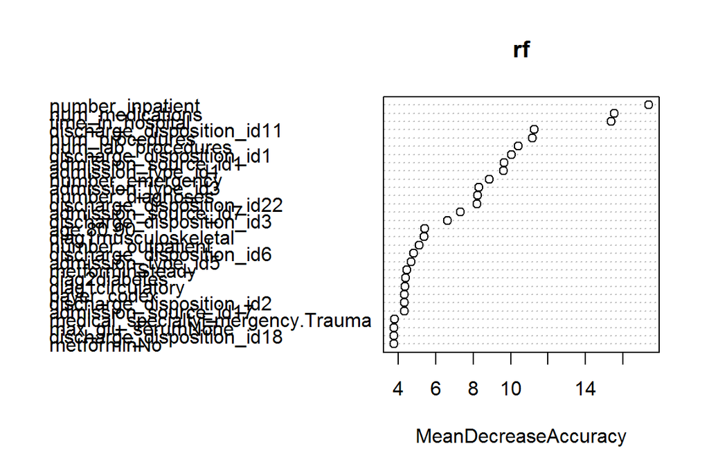

```
##                                                       MeanDecreaseAccuracy
## raceAfricanAmerican                                            0.643520842
## raceAsian                                                      1.160430572
## raceCaucasian                                                  1.623519619
## raceHispanic                                                   1.156399226
## raceOther                                                      0.058709615
## racex                                                          0.046365470
## genderFemale                                                   2.393887804
## genderMale                                                     0.654510479
## age.0.10.                                                     -1.420297232
## age.10.20.                                                     1.733295874
## age.20.30.                                                    -0.035721596
## age.30.40.                                                     1.959438977
## age.40.50.                                                     2.215496558
## age.50.60.                                                     1.723723728
## age.60.70.                                                     0.368345315
## age.70.80.                                                    -0.434529288
## age.80.90.                                                     5.409381326
## age.90.100.                                                    1.959125133
## weight.0.25.                                                   0.440035821
## weight.100.125.                                               -2.186417827
## weight.125.150.                                               -0.933167443
## weight.150.175.                                               -2.233364514
## weight.175.200.                                               -2.041219598
## weight.25.50.                                                 -0.577758301
## weight.50.75.                                                 -0.856198758
## weight.75.100.                                                 3.023028854
## weight.200                                                     0.000000000
## weightx                                                        3.701877790
## admission_type_id1                                             9.631789121
## admission_type_id2                                             3.666659337
## admission_type_id3                                             8.286670739
## admission_type_id4                                            -2.526431619
## admission_type_id5                                             4.689305079
## admission_type_id6                                             3.530129712
## admission_type_id7                                             0.000000000
## admission_type_id8                                            -1.256118252
## discharge_disposition_id1                                     10.042965188
## discharge_disposition_id10                                     0.000000000
## discharge_disposition_id11                                    11.254370283
```

[output cut: 232 more lines]

```
## diag2NA                                                       -0.567269184
## diag2neoplasms                                                 1.072098776
## diag2other                                                    -0.129660673
## diag2respiratory                                               0.474639684
## diag3circulatory                                               2.864905608
## diag3diabetes                                                  3.306703810
## diag3digestive                                                -0.890884503
## diag3genitourinary                                            -0.536149137
## diag3injury                                                   -0.842104490
## diag3musculoskeletal                                          -1.186988187
## diag3NA                                                        3.644047817
## diag3neoplasms                                                 1.232727344
## diag3other                                                     1.480314472
## diag3respiratory                                               0.300809660
## A1Ctest                                                        2.911023271
```

```r
# RF needs factors
rftim <- Sys.time()
rf <- randomForest(target~., data = ddf_train, ntree = 100, importance=T)
rftim <- Sys.time() - rftim

as.data.frame(varImpPlot(rf, type = 1))
```

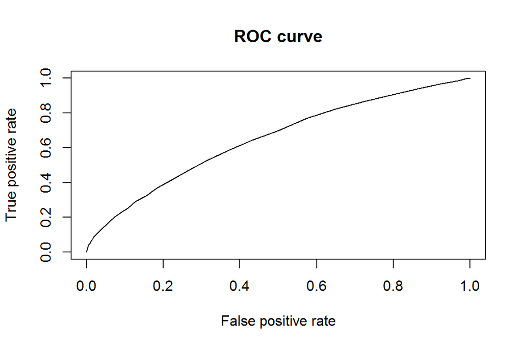

```r
pred_rf <- prediction(predict(rf, ddf_test, type = "prob")[,"1"], ddf_test$target)

# MSE
rfmse <- mean(as.data.frame(predict(rf, ddf_test, type = "prob")[,"1"])[,1] - (as.numeric(ddf_test$target)-1))^2
# ROC
plot(performance(pred_rf,"tpr","fpr"), main="ROC curve")
```

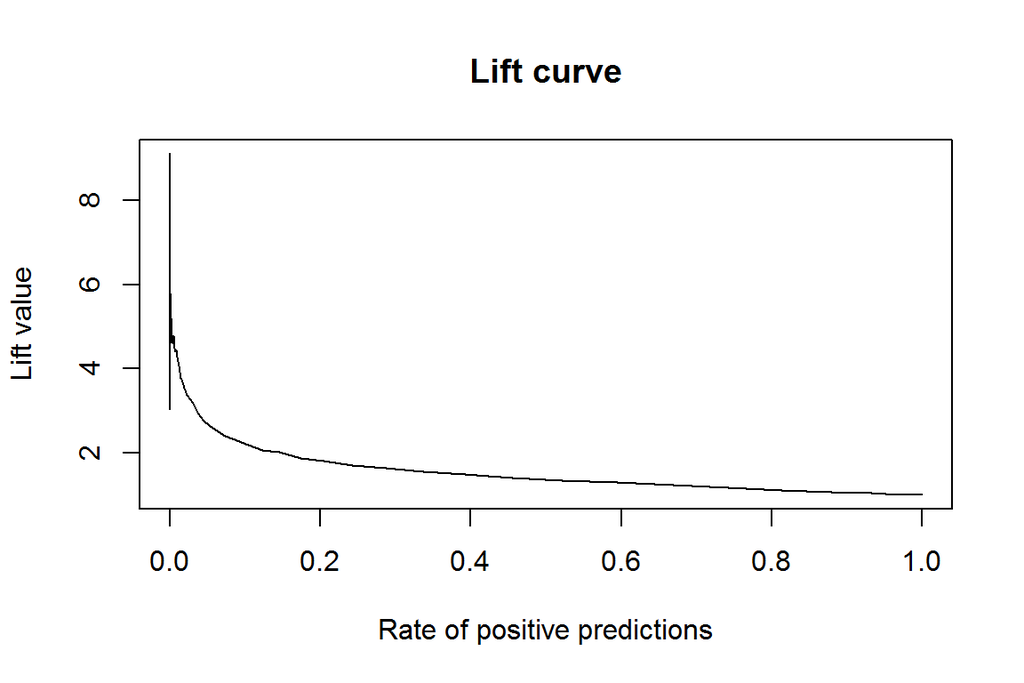

```r
# lift chart
plot(performance(pred_rf,"lift","rpp"), main="Lift curve")
```

```r
#AUC
rfauc <- as.numeric(performance(pred_rf,"auc")@y.values)

rf
```

```
##
## Call:
##  randomForest(formula = target ~ ., data = ddf_train, ntree = 100,      importance = T)
##                Type of random forest: classification
##                      Number of trees: 100
## No. of variables tried at each split: 16
##
##         OOB estimate of  error rate: 11.1%
## Confusion matrix:
##       0  1 class.error
## 0 45202 18 0.000398054
## 1  5628 33 0.994170641
```

```r
pander(c(mse=rfmse,auc=rfauc,time=rftim))
```

| mse | auc | time |
| --- | --- | --- |
| 6.55e-05 | 0.6502 | 22.29 |

### GBM with cross validation

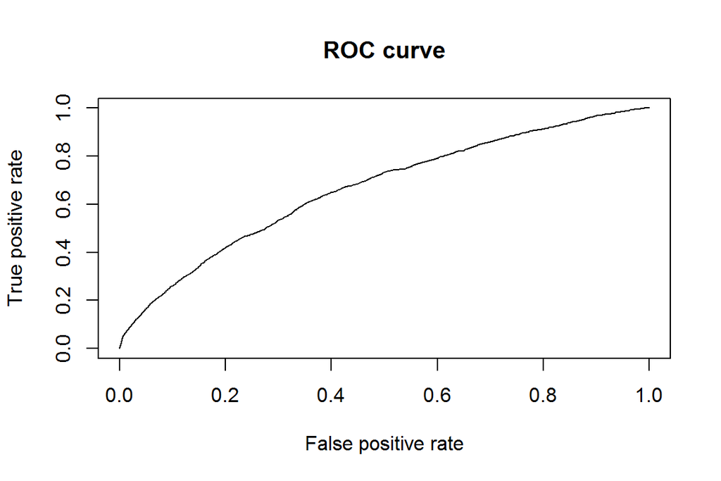

```r
gbmtim <- Sys.time()
gbm <- gbm(target ~ ., data = df_train, distribution = "bernoulli",
          n.trees = 100, interaction.depth = 10, shrinkage = 0.01, cv.folds = 5)
gbmtim <- Sys.time() - gbmtim

pred_gbm <- prediction(predict(gbm,df_test,100),df_test$target)

# MSE
gbmmse <- mean((as.data.frame(predict(gbm, df_test,100)) - dd_test$target)^2)
# ROC
plot(performance(pred_gbm,"tpr","fpr"), main="ROC curve")
```

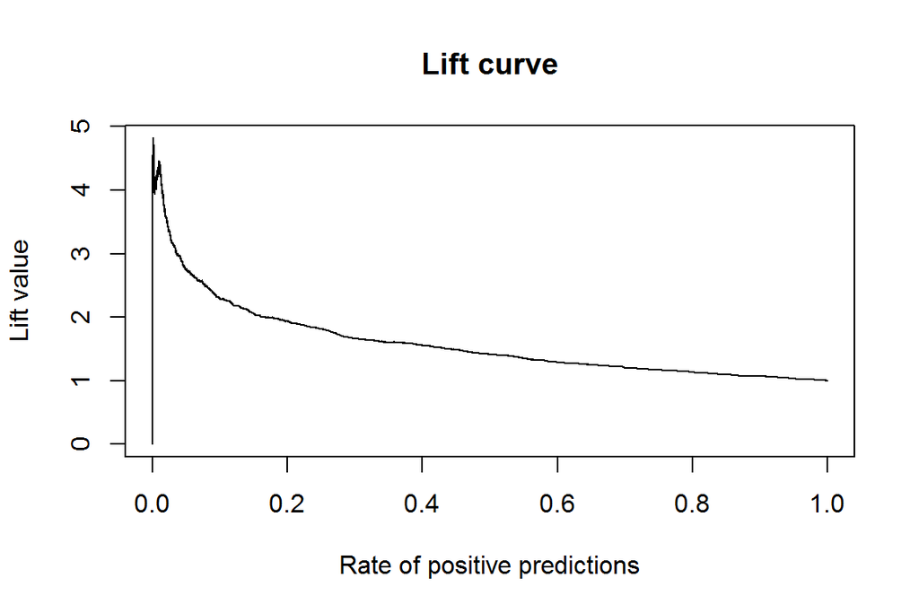

```r
# lift chart
plot(performance(pred_gbm,"lift","rpp"), main="Lift curve")
```

```r
#AUC
gbmauc <- as.numeric(performance(pred_gbm,"auc")@y.values)

gbm
```

```
## gbm(formula = target ~ ., distribution = "bernoulli", data = df_train,
##     n.trees = 100, interaction.depth = 10, shrinkage = 0.01,
##     cv.folds = 5)
## A gradient boosted model with bernoulli loss function.
## 100 iterations were performed.
## The best cross-validation iteration was 100.
## There were 45 predictors of which 21 had non-zero influence.
```

```r
pander(c(mse=gbmmse,auc=gbmauc,time=gbmtim))
```

| mse | auc | time |
| --- | --- | --- |
| 5.129 | 0.6661 | 3.836 |

## Modelling with H2O

```r
h_train <- as.h2o(d_train)
h_valid <- as.h2o(d_valid)
h_test <- as.h2o(d_test)
```

### Random forest

```r
hrftim <- Sys.time()
  hrf <- h2o.randomForest(x = 1:45, y = 46,
            training_frame = h_train,
            mtries = -1, ntrees = 100, max_depth = 20, nbins = 50
            )
```

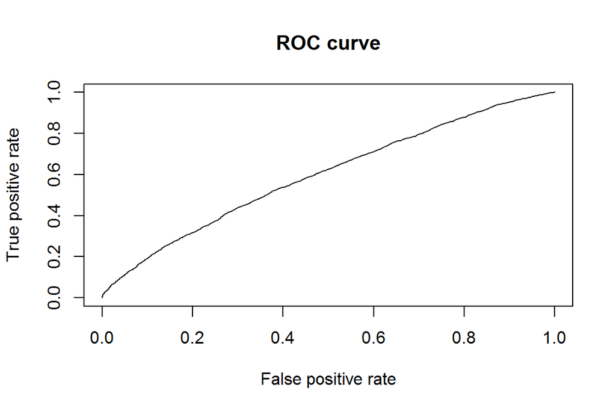

```r
hrftim <- Sys.time() - hrftim

pred_hrf <- prediction(as.data.frame(h2o.predict(hrf, h_test)$predict),as.data.frame(h_test$target))

# MSE
hrfmse <- h2o.mse(h2o.performance(hrf, h_test))
# ROC
plot(performance(pred_hrf,"tpr","fpr"), main="ROC curve")
```

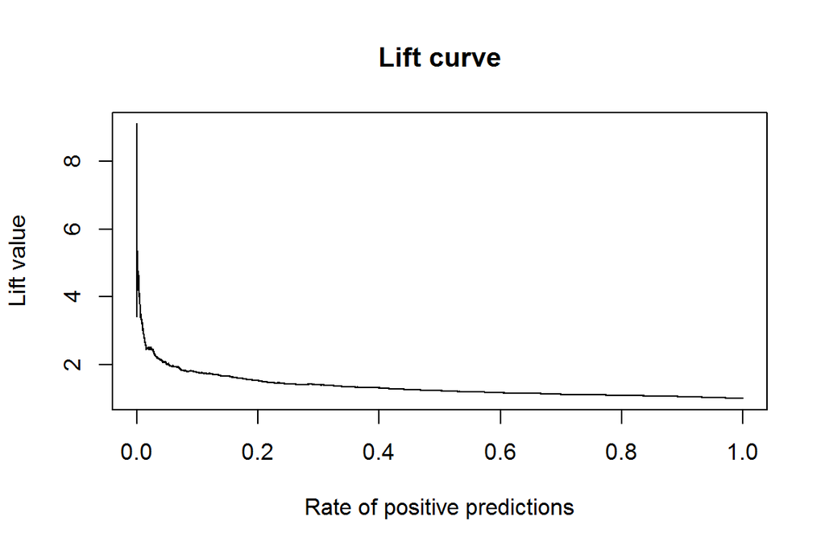

```r
# lift chart
plot(performance(pred_hrf,"lift","rpp"), main="Lift curve")
```

```r
#AUC
hrfauc <- as.numeric(performance(pred_hrf,"auc")@y.values)

hrf
```

```
## Model Details:
## ==============
##
## H2ORegressionModel: drf
## Model ID:  DRF_model_R_1457253210313_150
## Model Summary:
##   number_of_trees model_size_in_bytes min_depth max_depth mean_depth
## 1             100             3233265        20        20   20.00000
##   min_leaves max_leaves mean_leaves
## 1       2094       3409  2773.05000
##
##
## H2ORegressionMetrics: drf
## ** Reported on training data. **
## Description: Metrics reported on Out-Of-Bag training samples
##
## MSE:  0.09904416
## R2 :  -0.00165098
## Mean Residual Deviance :  0.09904416
```

```r
pander(c(mse=hrfmse,auc=hrfauc,time=hrftim))
```

| mse | auc | time |
| --- | --- | --- |
| 0.09761 | 0.5978 | 25.74 |

### GBM with cross validation

```r
hgbmtim <- Sys.time()
hgbm <- h2o.gbm(x = 1:45, y = 46,
          training_frame = h_train,
          max_depth = 20, ntrees = 100, learn_rate = 0.01, nbins = 50,
          nfolds = 5,
          stopping_rounds = 3, stopping_tolerance = 1e-3)
```

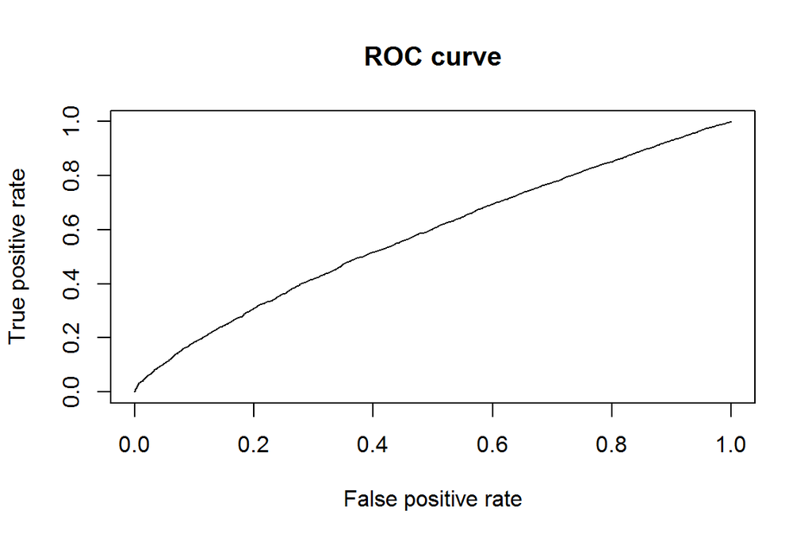

```r
hgbmtim <- Sys.time() - hgbmtim

pred_hgbm <- prediction(as.data.frame(h2o.predict(hgbm, h_test)$predict),as.data.frame(h_test$target))

# MSE
hgbmmse <- h2o.mse(h2o.performance(hgbm, h_test))
# ROC
plot(performance(pred_hgbm,"tpr","fpr"), main="ROC curve")
```

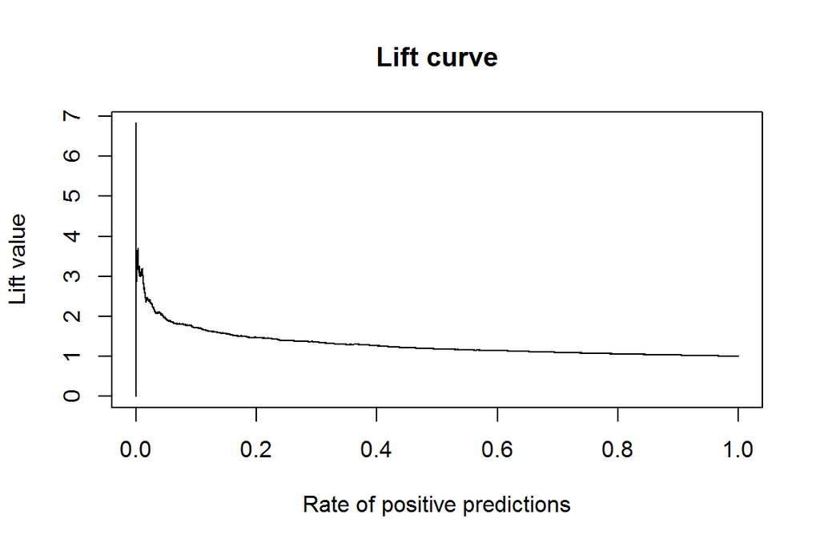

```r
# lift chart
plot(performance(pred_hgbm,"lift","rpp"), main="Lift curve")
```

```r
#AUC
hgbmauc <- as.numeric(performance(pred_hgbm,"auc")@y.values)

hgbm
```

```
## Model Details:
## ==============
##
## H2ORegressionModel: gbm
## Model ID:  GBM_model_R_1457253210313_155
## Model Summary:
##   number_of_trees model_size_in_bytes min_depth max_depth mean_depth
## 1              81             1908616        20        20   20.00000
##   min_leaves max_leaves mean_leaves
## 1       1538       2303  2015.72840
##
##
## H2ORegressionMetrics: gbm
## ** Reported on training data. **
##
## MSE:  0.081716
## R2 :  0.1735917
## Mean Residual Deviance :  0.081716
##
##
##
## H2ORegressionMetrics: gbm
## ** Reported on cross-validation data. **
## Description: 5-fold cross-validation on training data
##
## MSE:  0.09793735
## R2 :  0.009542358
## Mean Residual Deviance :  0.09793735
```

```r
pander(c(mse=hgbmmse,auc=hgbmauc,time=hgbmtim))
```

| mse | auc | time |
| --- | --- | --- |
| 0.09682 | 0.5798 | 2.392 |

### GBM with grid search

```r
hgmbg <- h2o.grid("gbm", x = 1:45, y = 46,
            training_frame = h_train, validation_frame = h_valid,
            hyper_params = list(ntrees = c(50,100,500),
                                max_depth = c(5,10,20),
                                learn_rate = c(0.01,0.1),
                                nbins = 200),
            stopping_rounds = 5, stopping_tolerance = 1e-3)
result <-
do.call(rbind, lapply(hgmbg@model_ids, function(m_id) {
  mm <- h2o.getModel(m_id)
  hyper_params <- mm@allparameters
  data.frame(m_id = m_id,
             mse = h2o.mse(mm, test=TRUE),
             #auc = h2o.auc(mm, test=TRUE),
             #auc = h2o.performance(mm, h_test)@metrics$AUC,
             ntrees = hyper_params$ntrees,
             max_depth = hyper_params$max_depth,
             learn_rate = hyper_params$learn_rate )
})) %>% arrange(mse)

pander(result[,-1 ])
```

| mse | ntrees | max_depth | learn_rate |
| --- | --- | --- | --- |
| 0.06039 | 100 | 20 | 0.1 |
| 0.06088 | 500 | 20 | 0.1 |
| 0.06762 | 50 | 20 | 0.1 |
| 0.06792 | 500 | 20 | 0.01 |
| 0.08377 | 100 | 20 | 0.01 |
| 0.08554 | 500 | 10 | 0.01 |
| 0.08958 | 50 | 20 | 0.01 |
| 0.08975 | 500 | 10 | 0.1 |
| 0.08975 | 100 | 10 | 0.1 |
| 0.08975 | 50 | 10 | 0.1 |
| 0.09208 | 100 | 10 | 0.01 |
| 0.09332 | 500 | 5 | 0.01 |
| 0.09439 | 50 | 5 | 0.1 |
| 0.09439 | 100 | 5 | 0.1 |
| 0.09439 | 500 | 5 | 0.1 |
| 0.09456 | 50 | 10 | 0.01 |
| 0.09556 | 100 | 5 | 0.01 |
| 0.09659 | 50 | 5 | 0.01 |

### Neural network

```r
hnntim <- Sys.time()
hnn <- h2o.deeplearning(x = 1:45, y = 46,
          training_frame = h_train, validation_frame = h_valid,
          activation = "Rectifier", hidden = c(200,200), epochs = 100,
          stopping_rounds = 3, stopping_tolerance = 0)
```

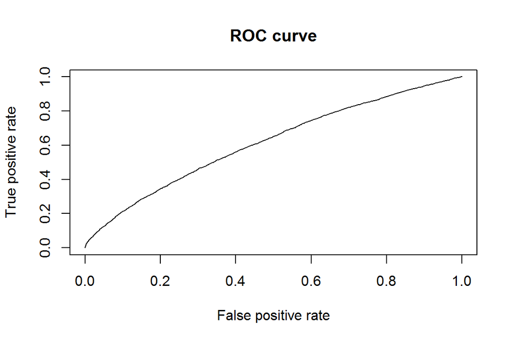

```r
hnntim <- Sys.time() - hnntim

pred_hnn <- prediction(as.data.frame(h2o.predict(hnn, h_test)$predict),as.data.frame(h_test$target))

# MSE
hnnmse <- h2o.mse(h2o.performance(hnn, h_test))
# ROC
plot(performance(pred_hnn,"tpr","fpr"), main="ROC curve")
```

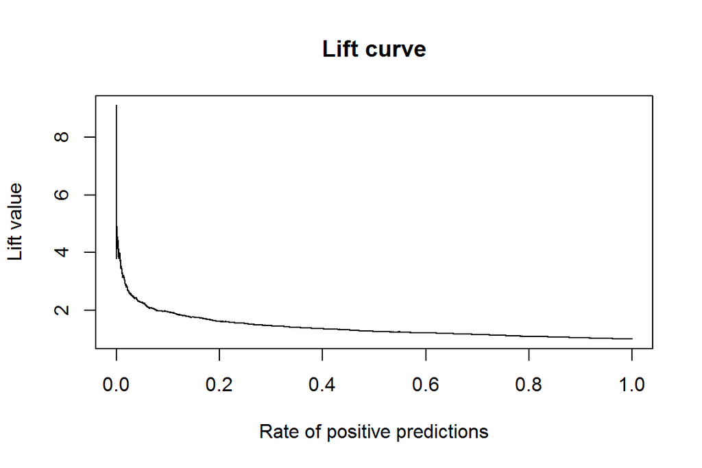

```r
# lift chart
plot(performance(pred_hnn,"lift","rpp"), main="Lift curve")
```

```r
#AUC
hnnauc <- as.numeric(performance(pred_hnn,"auc")@y.values)

hnn
```

```
## Model Details:
## ==============
##
## H2ORegressionModel: deeplearning
## Model ID:  DeepLearning_model_R_1457253210313_162
## Status of Neuron Layers: predicting target, regression, gaussian distribution, Quadratic loss, 42Â 401 weights/biases, 506,6 KB, 819Â 860 training samples, mini-batch size 1
##   layer units      type dropout       l1       l2 mean_rate rate_RMS
## 1     1     9     Input  0.00 %
## 2     2   200 Rectifier  0.00 % 0.000000 0.000000  0.033798 0.020259
## 3     3   200 Rectifier  0.00 % 0.000000 0.000000  0.144597 0.186131
## 4     4     1    Linear         0.000000 0.000000  0.001468 0.000964
##   momentum mean_weight weight_RMS mean_bias bias_RMS
## 1
## 2 0.000000    0.008914   0.097373  0.418128 0.058147
## 3 0.000000   -0.017918   0.069924  0.955105 0.024134
## 4 0.000000    0.003378   0.049802  0.066959 0.000000
##
##
## H2ORegressionMetrics: deeplearning
## ** Reported on training data. **
## Description: Metrics reported on temporary training frame with 10030 samples
##
## MSE:  0.09825964
## R2 :  0.02537287
## Mean Residual Deviance :  0.09825964
##
##
## H2ORegressionMetrics: deeplearning
## ** Reported on validation data. **
## Description: Metrics reported on temporary (load-balanced) validation frame
##
## MSE:  0.09838144
## R2 :  0.02737888
## Mean Residual Deviance :  0.09838144
```

```r
pander(c(mse=hnnmse,auc=hnnauc,time=hnntim))
```

| mse | auc | time |
| --- | --- | --- |
| 0.09559 | 0.6146 | 1.277 |

### Neural network with regularization (L1, L2, dropout)

```r
hnnrtim <- Sys.time()
hnnr <- h2o.deeplearning(x = 1:45, y = 46,
          training_frame = h_train, validation_frame = h_valid,
          activation = "RectifierWithDropout", hidden = c(200,200), epochs = 100,
          input_dropout_ratio = 0.2, hidden_dropout_ratios = c(0.2,0.2),
          l1 = 1e-4, l2 = 1e-4,
          stopping_rounds = 3, stopping_tolerance = 0)
```

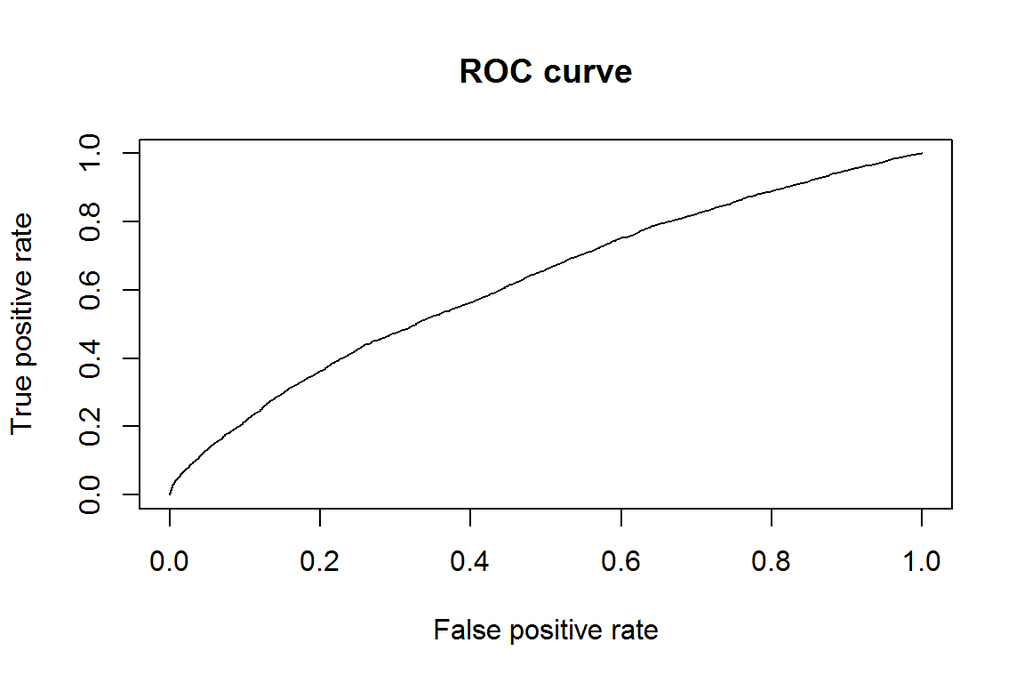

```r
hnnrtim <- Sys.time() - hnnrtim

pred_hnnr <- prediction(as.data.frame(h2o.predict(hnnr, h_test)$predict),as.data.frame(h_test$target))

# MSE
hnnrmse <- h2o.mse(h2o.performance(hnnr, h_test))
# ROC
plot(performance(pred_hnnr,"tpr","fpr"), main="ROC curve")
```

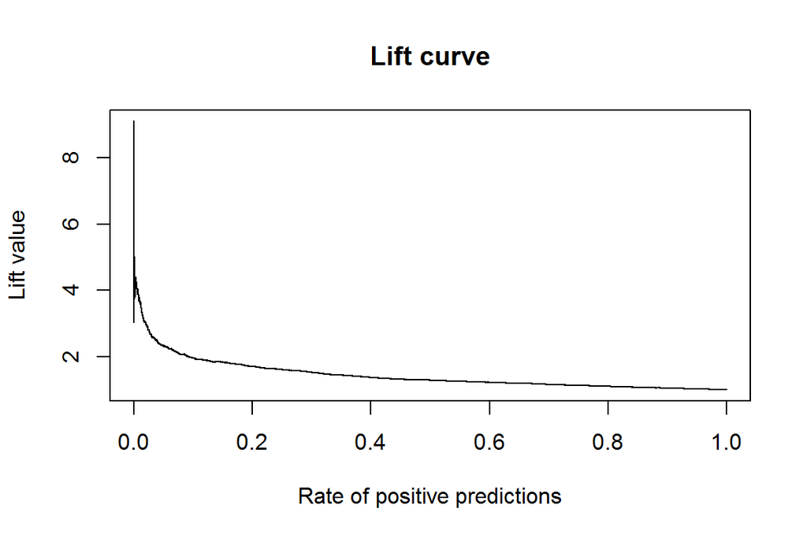

```r
# lift chart
plot(performance(pred_hnnr,"lift","rpp"), main="Lift curve")
```

```r
#AUC
hnnrauc <- as.numeric(performance(pred_hnnr,"auc")@y.values)

hnnr
```

```
## Model Details:
## ==============
##
## H2ORegressionModel: deeplearning
## Model ID:  DeepLearning_model_R_1457253210313_167
## Status of Neuron Layers: predicting target, regression, gaussian distribution, Quadratic loss, 42Â 401 weights/biases, 506,6 KB, 1Â 092Â 948 training samples, mini-batch size 1
##   layer units             type dropout       l1       l2 mean_rate
## 1     1     9            Input 20.00 %
## 2     2   200 RectifierDropout 20.00 % 0.000100 0.000100  0.156557
## 3     3   200 RectifierDropout 20.00 % 0.000100 0.000100  0.532787
## 4     4     1           Linear         0.000100 0.000100  0.032615
##   rate_RMS momentum mean_weight weight_RMS mean_bias bias_RMS
## 1
## 2 0.246570 0.000000    0.002327   0.069541 -0.000550 0.026866
## 3 0.266814 0.000000   -0.004970   0.024672 -0.008708 0.065546
## 4 0.067846 0.000000   -0.004879   0.025471  0.081944 0.000000
##
##
## H2ORegressionMetrics: deeplearning
## ** Reported on training data. **
## Description: Metrics reported on temporary training frame with 10060 samples
##
## MSE:  0.09523687
## R2 :  0.03057886
## Mean Residual Deviance :  0.09523687
##
##
## H2ORegressionMetrics: deeplearning
## ** Reported on validation data. **
## Description: Metrics reported on temporary (load-balanced) validation frame
##
## MSE:  0.09797147
## R2 :  0.03143192
## Mean Residual Deviance :  0.09797147
```

```r
pander(c(mse=hnnrmse,auc=hnnrauc,time=hnnrtim))
```

| mse | auc | time |
| --- | --- | --- |
| 0.09528 | 0.6226 | 1.131 |

## Compaison of the models

The R models performed better (GBM, Logit) then H2O ones in prediction accuracy. Among H2O models the best performing was Deep Learning. But for this purpose the Decision tree seemed good choice but Logit overperformed it.

| Model | MSE | AUC | Time |
| --- | --- | --- | --- |
| Logit | 5.792 | 0.6683 | 3.436 |
| ClassTree | 0.1239 | 0.5711 | 34 |
| RandomForest | 6.55e-05 | 0.6502 | 22.29 |
| GBM /w cv | 5.129 | 0.6661 | 3.836 |
| H2O RandomForest | 0.09761 | 0.5978 | 25.74 |
| H2O GBM /w cv | 0.09682 | 0.5798 | 2.392 |
| DeapLearn | 0.09559 | 0.6146 | 1.277 |
| DeapLearn /w reg | 0.09528 | 0.6226 | 1.131 |